# Night-time Saftey Index

## Scenario

Melbourne is a vibrnt city with a 24h economy, as of a result transport authorities, city planners and concerned community members are increasingly worried about the night time saftey of the city. While melbourne has a thriving culture with many events, hospitality, shopping and public transport running late into the night. Not all parts of Melbourne is safe with the increased number of inccidents of crime occuring in city particularly in isolated walkways and streets with poor lighting. This raises concern in the community for the youth, elderly, women, students and shift workers alike. To address this problem, I have used the data from City of Melbourne open datasets. The implemented datasets include: - Street lighting - Pedestrian foot traffic - Public Transport stop locations.

By developing the Night time saftey Index, I aim to identify areas within melbourne that are considered high risk zones. Areas in which there is low visibility, little to no street lights, little foot traffic and is not near a public transport stop. Conversly areas will be mared as safer if there is higher visibility, more foot traffic as this acts as a percieved layer of saftey and access to public transport, as generally the likleyhood of people would be higher. The index is developed based on understanding crime data on low light and low populas areas.

With the use of the Night-time saftey index, we can strive to improve these areas improve the saftey index and build a more safe and inclusive city for all members of the community.

As a student who commutes to the city regularly for work and univesity, I end up often traveling after dark. I want to know which areas in melbourne are safe or dangerous at night. So that I can plan a safer routes, avoid areas that are dangerous and feel confident that I will be safe moving through the city at night.

What this use case will teach you

At the end of this use case you will:

- Demonstraite the ability to retrieve and process data from public API
- Data cleaning and preprocessing techniques on geospatial and time data
- Perform basic aggregation and filtering methods
- Perform analysis using latitude and longitude data
- Implement data visualisation techniques

## Introduction

This use case aims to develop a Night time saftey index by combining datasets from the City of Melbourne Open data project. By combing the data, it can be then assessed and visualised to demonstrate the varying saftey level for different areas during the night hours. The project goal is to disover areas with low visablity, low foot traffic or infrastructure to aid in future developmenet to create a safer melbourne for all. The analysis is drawn from the datasets below accessed via the Melbourne open data API. By combining combining these datasets the project aims to create a data driven solution to create a safer and inclusive city.

Dataset Links

- Bus Stops data link: https://data.melbourne.vic.gov.au/explore/dataset/bus-stops/api/
- Street Lighting data link: https://data.melbourne.vic.gov.au/explore/dataset/street-lights-with-emitted-lux-level-council-owned-lights-only/api/
- Pedestrian counting link: https://data.melbourne.vic.gov.au/explore/dataset/pedestrian-counting-system-monthly-counts-per-hour/api/
- Feautured light data link: https://data.melbourne.vic.gov.au/explore/dataset/feature-lighting-including-light-type-wattage-and-location/api/

### Geospatial Visualisation of Street Lights

**Description:**

The scatter plot below plots the geographical distribution of street lights across the mapped area. Each point represents a single street light. Visualising provides a spatial context of the spread of the data and aids in discovering the light coverage and potential areas which are underlit.

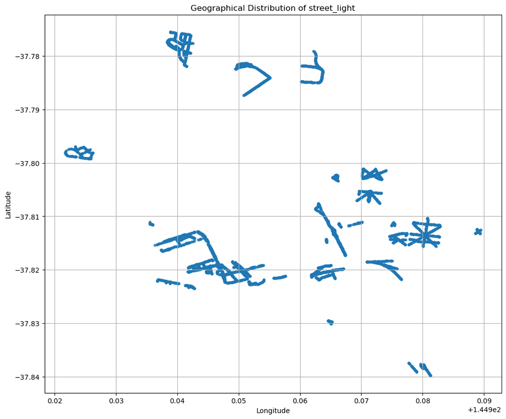

**Overview of Geospatial visualisation:**

The scatter plot has provided key insights into the datasets in particular the spread of the light datasets. As showen there are key areas that are missing that should be present when overlayed on a map of the city of melbourne. This takes into question the spread of the data what datasets are missing and what steps we cant take to account for the significant missing street light data.

### Importing feature light data

The data is fetched using the API and then the rows are renamed to latitude and longitude to keep consistant nameing porfile throughout all datasets.Enabling seamless geospatial analysis and integration with other location-based data

|  | asset_number | asset_description | lamp_type_lupvalue | lamp_rating_w | mounting_type_lupvalue | latitude | longitude | location |
| --- | --- | --- | --- | --- | --- | --- | --- | --- |
| 0 | 1544260 | Feature Lighting - Birrarung Marr | 13.0 | 70.0 | Pole: Multiple Fixed | -37.818239 | 144.971382 | {'lon': 144.9713815748613, 'lat': -37.81823859... |
| 1 | 1541782 | Feature Lighting - | 13.0 | 35.0 | Pole: Multiple Fixed | -37.822848 | 144.947094 | {'lon': 144.94709354140863, 'lat': -37.8228478... |
| 2 | 1542772 | Feature Lighting - | 12.0 | NaN | Pole: Multiple Fixed | -37.823150 | 144.947204 | {'lon': 144.9472041813461, 'lat': -37.82314998... |
| 3 | 1346470 | Feature Lighting - Docklands | 1.0 | NaN | Canopy | -37.817318 | 144.952251 | {'lon': 144.95225109118593, 'lat': -37.8173181... |
| 4 | 1539337 | Feature Lighting - Newquay Promenade between S... | 9.0 | NaN | Pole: Multiple Fixed | -37.814603 | 144.942694 | {'lon': 144.94269431917522, 'lat': -37.8146026... |
| ... | ... | ... | ... | ... | ... | ... | ... | ... |
| 8559 | 1347738 | Feature Lighting - Docklands | 1.0 | 18.0 | Wall | -37.824620 | 144.946620 | {'lon': 144.94662008927858, 'lat': -37.8246201... |
| 8560 | 1541845 | Feature Lighting - | NaN | NaN | Pole: Multiple Fixed | -37.823748 | 144.952091 | {'lon': 144.9520910323129, 'lat': -37.82374757... |
| 8561 | 1346811 | Feature Lighting - Docklands | 3.0 | 36.0 | Parapet | -37.817528 | 144.950016 | {'lon': 144.95001579629215, 'lat': -37.8175284... |
| 8562 | 1544683 | Feature Lighting - Seafarers Rest | 2.0 | 14.0 | Pole: Multiple Fixed | -37.822771 | 144.951655 | {'lon': 144.95165526864113, 'lat': -37.8227706... |
| 8563 | 1542075 | Feature Lighting - Arglye Square | 9.0 | NaN | Pole: Multiple Fixed | -37.802565 | 144.966134 | {'lon': 144.9661338329207, 'lat': -37.80256495... |

8564 rows × 8 columns

### Visualisation of Feature light's distribution of Lamp Wattage

**Description:**

The bar plot below visualises the distribution of lampwattage this gives us a visual representage of the light wattage. This will aid in deciding on the weightage of the safety score based on the light wattage.

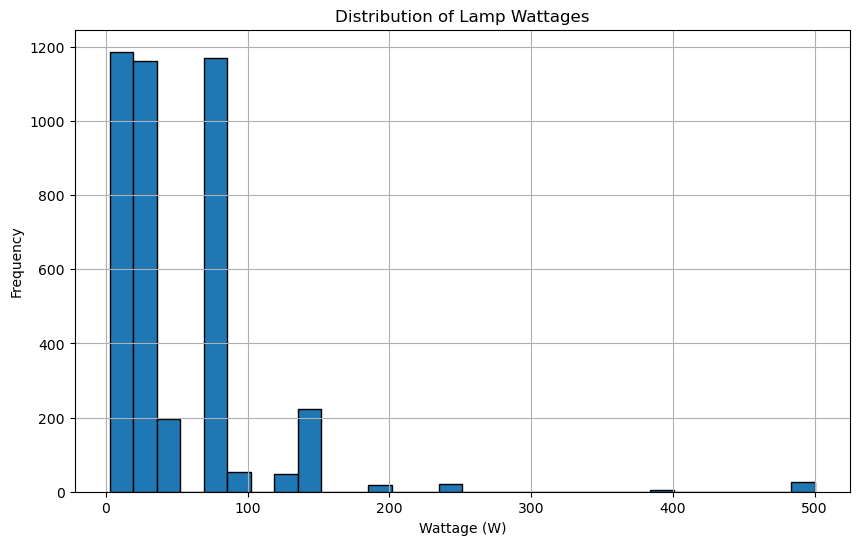

### Wattage Distribution Insight

**Interpretation:**  
The relatively low wattage per individual light may reflect a higher density based method with a higher concentration of lights, as each light require less power to produce sufficient illumination. This enables: * Better energy efficiency * Reduced light pollution *Even light distribution across high-density areas

**Implication for Analysis:**  
When evaluating visibility within an area, it is essential to taken into concideration both individual lamp wattage and the spatial density of lighting.

### Initialising `safety_score` for feature_light_df and Cleaning

**Description:**

### Geospatial Visualisation of Pedestrian Counting sensors

**Description:**

-The code cell below plots all the locaitons of all sensors using matplotlib. It demonstrates the spread of the sensors throughout Melbourne

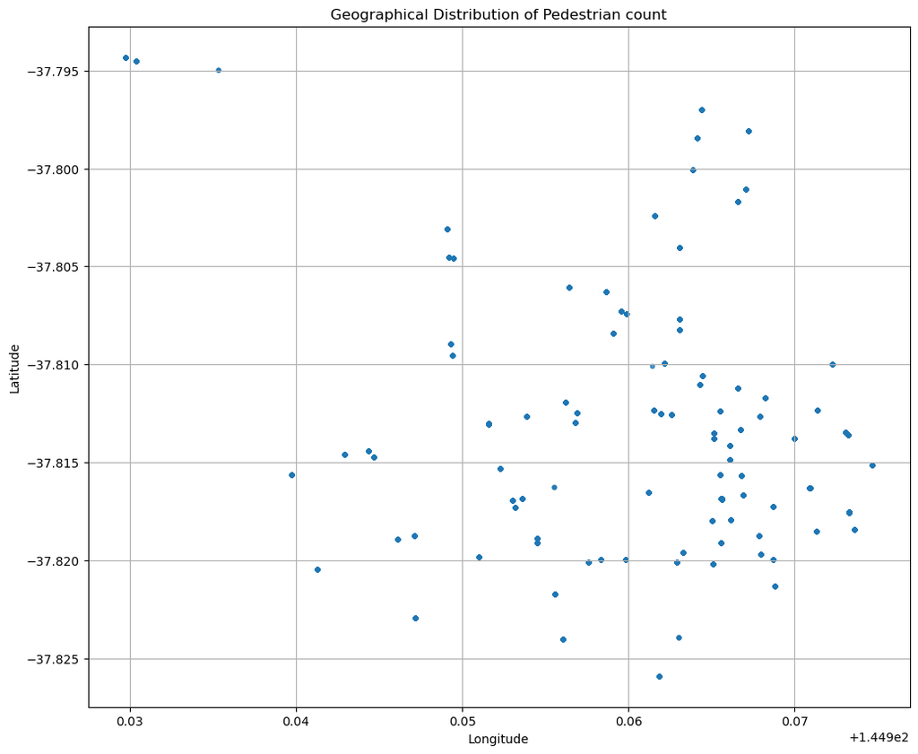

As seen with the results we cans see that there is a good spread of pedestrian count sensors throought the city. This is great news as it will ensure that we can reliably use the sensor data.

### Visualisation of Pedestrian Counts by Location

**Description:**

-The code cell below plots a bar plot of all the sensor locaitons using matplotlib. This will provide us with the visual representation of the more frequented locations within melbourne.

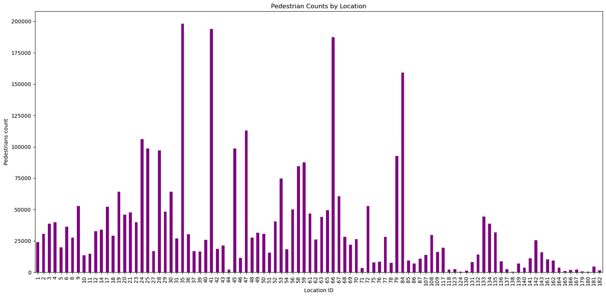

From the Graph:

### Visualising Landmarks

Viewing the landmarks on the map gives a good respresentation of the provided landmarks and the locations in which each land marks exist. The map contains unique Icons for each landmark and if you click on the icon it provides the description of the landmark.

Make this Notebook Trusted to load map: File -> Trust Notebook

[interactive chart not shown]

#### What can we see

- The spread of the key landmarks within melbourne
- What landmarks exisit within the city
- Better understanding on what steps to take to assign landmark score values

### Landmark score

Below the landmark saftey score is assigned to each of the key landmarks within the dataset. The scoring is determined by the type of land use and its impact on pedestrian activity, lighting and surveillance. Locations such as health services, education centres and community hubs have received an increased score due to the frequent foot traffic and established infrastructure present in those locations. On the other hand locations such as vacant lands, warehouses and industrial zones are assined lower scores due to lower pedestrian activity, reduced visibility and underutilisation. Furthermore these areas during the night are often not visited and remain empty. This scoring enables us to quantify various landmarks and how they contribute or detract from the night time safety in Melbourne.

#### Visualisation of Safety Score Distribution

**Description:** The code cell implements a Bar graph of the Saftey Score for each landmark, with a clear visual representation of the spread of the data based ont he landmark.

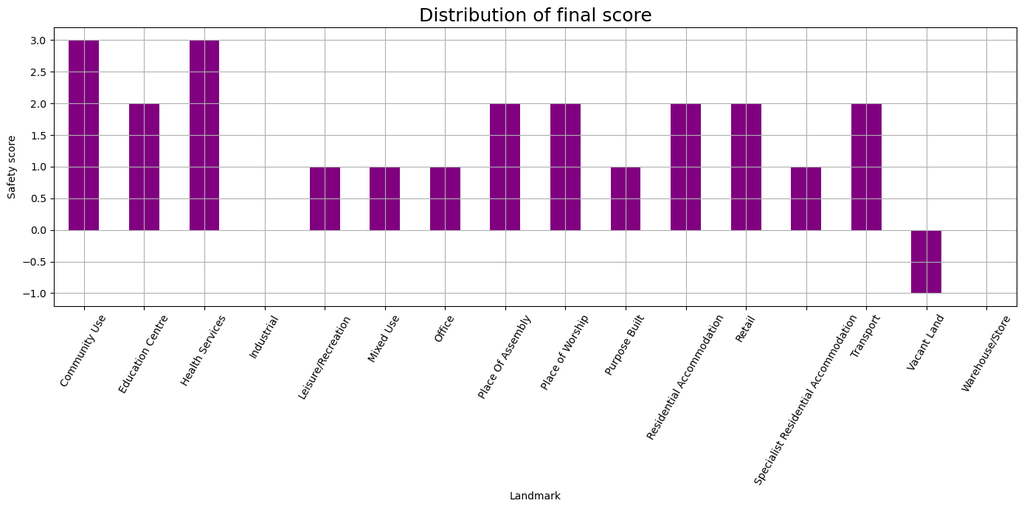

Areas that are low value are Warehouse/store and industrial with a value of 0. With the only negative score assigned to vacant land.

#### Geospatial Visualisation of Bus Stops

**Description:** The code cell below plots all the location of the bus stops within the `bus_stops_df` as a scatter plot. This will server as a visual representation of the spread of the data and aid in decisions based on the bus stop datasets.

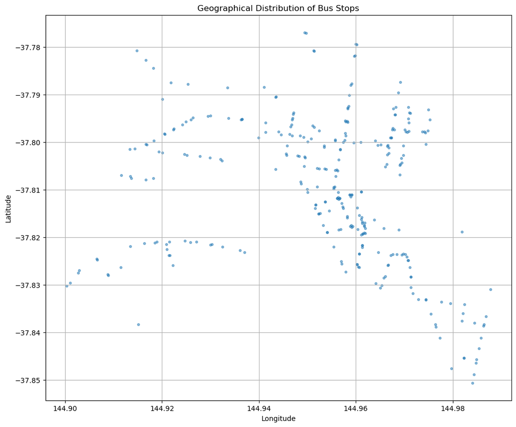

As seen by the scatter plot the spread demonstrates how well distributed the bus stop data is.

### Visualising Dataset using folium

I have iterated through each of the datasets and coloured the elements respectfully blue: bus stops, red: pedestrian count sensor location, yellow: street lights. This provides a visual guid to understand the location of each of the street lights, location of each of the bus stops and the location of each of the pedestrain sensors with this informaiton we can get a better understanding on how to further progress on the project what data is scarse and what areas need more data sources to produce reliable information.

Make this Notebook Trusted to load map: File -> Trust Notebook

[interactive chart not shown]

### Visualisation Summary of Spatial Data

The output generated is an interactive map of the Melbourne CBD featuring:

- **Yellow dots**: Locations of council-owned **street lights**
- **Blue dots**: **Bus stop** locations
- **Red dots**: **Pedestrian sensor** locations

From the map, several key insights can be drawn:

- Street light coverage is uneven across the city. Lighting is heavily concentrated in certain zones while some areas are noticeably lacking.
- Pedestrian sensors are installed only at specific points, which means that pedestrian traffic data is not uniformly available city-wide.
- This limitation highlights the need for extrapolation and data augmentation in areas lacking direct measurements .
- Visualising this spatial data has proven to be highly informative it provides critical context to guide the design of a more accurate Night-Time Safety Index.

The visualisation acts as both a planning tool to better understand urban safety infrastructure coverage.

### Grouping by Latitude and Longitude Grid Bins

This section of the notebook prepares all of the datasets for merging and incorporates the street light density into the **Night-Time Safety Index** calclualtion.

**Description:**

1. **Safety Score Renaming**
- Every dataset's `safety_score` has to changed to an appropriate unique identifier so that the data may be merged into a singular dataset.
2. **Location Binning**
- All datasets have been allocated latitude and longitude bins of precision 4, which is a rounding precision which works out to 11 meters. The spatial bins will aid in the implementation of merging features as per there proximity. The location binning has also aided in the impplementation of the light density.
3. **Light Density**
- light density was implemented to account for the amount of light within a location bin if the weightage of the light was low but there are many lights it would account for the low wattage. To implement this
- I have first combined both light datasets into one. This allows for there to be one set of lat and lon bin. I then grouped the data by lat_bin and long_bin by size as there would be in some cases overlapping light data within the same location bin. I then put the size into a new column light density.
- The light data was then normalised so that it would not skew the data heavily in favour of light density as some locations had high light density. Light density safety score would not exceed a value of 4 with a min of 0 to keep it in range with other safety scores.
4. **Safety Feature Consolidation**
- A list of simplified dataframes is created, each containing `lat_bin`, `lon_bin`, and its respective safety-related score. These will later be merged to compute the **final safety score per grid cell**.

### EDA on `final_safety_score`

Exploritory data analysis is done on the final safety score to ensure the spread of values is reasonalbe and so that there are no extreme outliers. This ensures that the final safety score has functioned as intended and the results have been successful.

```
count    20573.000000
mean         0.482831
std          0.191851
min         -0.142857
25%          0.285714
50%          0.428571
75%          0.571429
max          1.285714
Name: final_safety_score, dtype: float64
```

Looking at the results we can see that there are 20573 location grids, with a mean final_safety_score: 0.48 this further dispalays the spread of the data is well distributed. We can see the max final safety score is 1.29 and the min is -0.14.

### Visualisation on the Distribution of Final Safety Score

The cell below provides a histogram of the distribution of values so that is to ensure the spread is even.

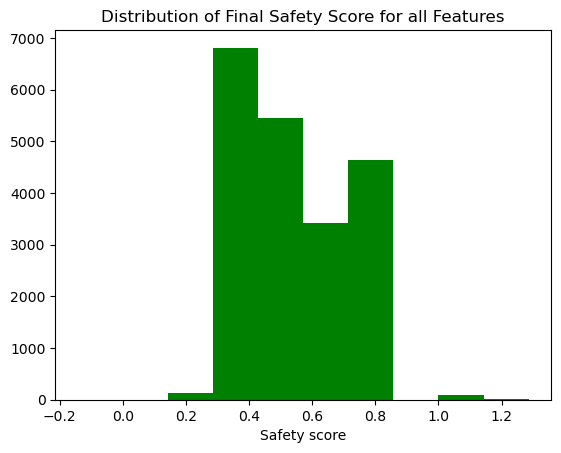

The spread of the data is well distributed and reflects the results obtained earlier.

### Heatmap Visualisation of Final Safety Score

This section generates an interactive heatmap to visualise the calculated `final_safety_score` across Melbournes city.

#### Description:

- A **Folium map** is created, centered on Melbourne's CBD.
- The `heat_data` list extracts the `lat_bin`, `lon_bin`, and corresponding `final_safety_score` from the `combined_df` dataframe.
- A heat layer is added using `folium.plugins.HeatMap()`, where:
  - Each point on the map corresponds to a geographic bin (rounded lat/lon).
  - The **intensity of the heat** is based on the `final_safety_score`, highlighting areas of varying night-time safety.
  - Higher scores produce a "hotter" (brighter) color, typically representing **safer** areas.

This heatmap provides an intuitive geospatial understanding of the night time safety index.

Make this Notebook Trusted to load map: File -> Trust Notebook

[interactive chart not shown]

### Explanation

The heat map provides a clear outline of areas of which that are considered safe, As seen these locations are marked in red and and the darker blue areas indicate areas that are less safe. The grid doesnt cover the whole of melbourne as seen by the map but provides a good overview of location that do cover it regions not covered dont have any colouring present. We can see that the main regions in which the heatmap indicates are safe are near trainstations is working as expected, we can see a clearly see the areas which are red and busy higher traffic areas. The Docklands area performs significantly well as the featured light data is present within that location, as well as the density of light within that region has awarded it a higher value.

## Conclusion: Night Time Safety Index

Through feature engineering and location grid binning, I was able to normalize datasets and generate a combined safety score for each location grid. The resulting heatmap clearly highlights areas of concern, as well of areas in which good industrial development has taken palce and which are safer.

The index is not only limited to use for individuals who are travelling at night and would like to avoid areas which are dangerous or individuals who are trying to get home safely. It provides an insight into safety within the community to city planners and local authorities in determining the gaps in safety. There is still so much to explore with the night time safety index. When developing the index I had a large part of the city lighting data missing, as of a resault I had contacted City of Melbourne to find access to the light data, but was unfortunatly unable to recieve the data in time. With the completed dataset it will provide a more accurate night time safety index further improving the safety index.

This index serves as a foundation for future enhancements such as incorporating real-time incident reports or machine learning models to predict safety fluctuations. Finally, the Night Time Safety Index is a scalable framework that promotes smarter, safer urban environments through transparent, open data analytics.